# BEST_fish_tidy

GG

4/12/2018

```r
library(tidyverse)
library(readxl)
library(janitor)
library(dbplyr)
final_fish2 <- read_csv("~/Documents/fish_tidy2.csv")
head(final_fish2)
```

```
## # A tibble: 6 x 9
##   date                survey site  species  transect  size density biomass
##   <dttm>               <int> <chr> <chr>    <chr>    <int>   <int>   <dbl>
## 1 2017-08-07 00:00:00      1 XL    Seriola… t1           5       0      0.
## 2 2017-08-07 00:00:00      1 XL    Seriola… t1          10       0      0.
## 3 2017-08-07 00:00:00      1 XL    Seriola… t1          15       0      0.
## 4 2017-08-07 00:00:00      1 XL    Seriola… t1          20       0      0.
## 5 2017-08-07 00:00:00      1 XL    Seriola… t1          25       0      0.
## 6 2017-08-07 00:00:00      1 XL    Seriola… t1          30       0      0.
## # ... with 1 more variable: trophic_guild <chr>
```

Mean biomass of each trophic group per survey per site

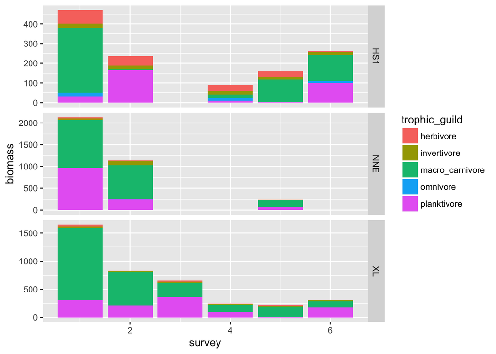

```r
ggplot(data = final_fish2, aes(x = survey, y=biomass, fill = trophic_guild)) + geom_bar(stat = "summary", fun.y = "mean") + facet_grid(site~., scales = "free")
```

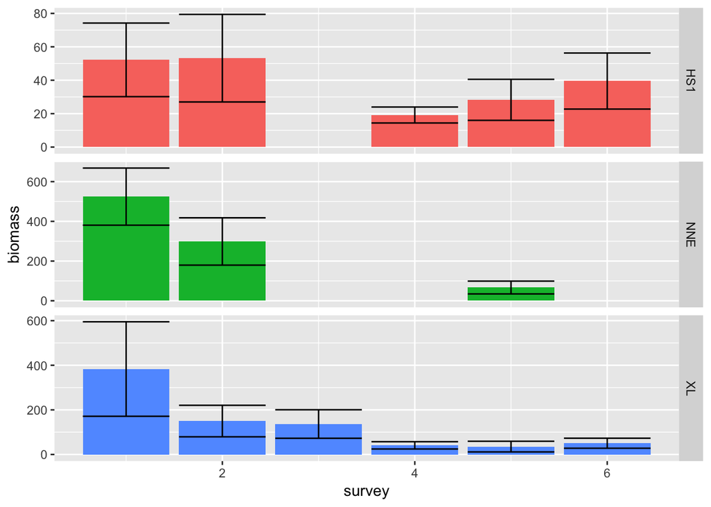

```r
ggplot(data = final_fish2, aes(x = survey, y=biomass, fill = site)) + geom_bar(stat = "summary", fun.y = "mean") + facet_grid(site~., scales = "free") + theme(legend.position = "none") + stat_summary(geom = "errorbar", fun.data = mean_se)
```

Anova analysis on overall biomass between surveys and sites: data square root transformed to meet the assumptions

```r
anova1 <- aov(sqrt(biomass) ~ as.character(survey) * site, data = final_fish2)
summary.aov(anova1)
```

```
##                             Df Sum Sq Mean Sq F value   Pr(>F)
## as.character(survey)         5   4007   801.4   6.669 3.51e-06 ***
## site                         2   2524  1262.1  10.503 2.86e-05 ***
## as.character(survey):site    6   1179   196.6   1.636    0.133
## Residuals                 2614 314118   120.2
## ---
## Signif. codes:  0 '***' 0.001 '**' 0.01 '*' 0.05 '.' 0.1 ' ' 1
```

```r
TukeyHSD(anova1)
```

```
##   Tukey multiple comparisons of means
##     95% family-wise confidence level
##
## Fit: aov(formula = sqrt(biomass) ~ as.character(survey) * site, data = final_fish2)
##
## $`as.character(survey)`
##            diff       lwr         upr     p adj
## 2-1 -1.13689095 -3.051181  0.77739899 0.5360608
## 3-1 -1.69908428 -4.160170  0.76200188 0.3606348
## 4-1 -3.08230912 -5.075207 -1.08941088 0.0001557
## 5-1 -3.10904693 -5.023337 -1.19475699 0.0000558
## 6-1 -2.84140285 -4.938466 -0.74433995 0.0015933
## 3-2 -0.56219333 -3.048248  1.92386133 0.9875481
## 4-2 -1.94541817 -3.969070  0.07823350 0.0676588
## 5-2 -1.97215598 -3.918442 -0.02587012 0.0449049
## 6-2 -1.70451190 -3.830822  0.42179840 0.2000035
## 4-3 -1.38322484 -3.930303  1.16385294 0.6325620
## 5-3 -1.40996265 -3.896017  1.07609201 0.5870163
## 6-3 -1.14231857 -3.771698  1.48706056 0.8176512
## 5-4 -0.02673781 -2.050389  1.99691387 1.0000000
## 6-4  0.24090627 -1.956441  2.43825307 0.9996031
## 6-5  0.26764408 -1.858666  2.39395438 0.9992218
##
## $site
##              diff        lwr        upr     p adj
## NNE-HS1  2.492818  1.1173540  3.8682818 0.0000657
## XL-HS1   1.017270 -0.1048202  2.1393608 0.0848262
## XL-NNE  -1.475548 -2.8431427 -0.1079524 0.0307757
##
## $`as.character(survey):site`
##                     diff        lwr        upr     p adj
## 2:HS1-1:HS1 -0.002685732 -3.9910799  3.9857085 1.0000000
## 3:HS1-1:HS1           NA         NA         NA        NA
## 4:HS1-1:HS1 -0.534573190 -4.1801572  3.1110108 1.0000000
## 5:HS1-1:HS1 -0.614503655 -4.4637723  3.2347650 1.0000000
## 6:HS1-1:HS1 -0.190336303 -3.8797359  3.4990633 1.0000000
## 1:NNE-1:HS1  5.280960903  1.4316922  9.1302296 0.0002522
## 2:NNE-1:HS1  3.029093004 -0.8201757  6.8783617 0.3474936
## 3:NNE-1:HS1           NA         NA         NA        NA
## 4:NNE-1:HS1           NA         NA         NA        NA
```

[output cut: 129 more lines]

```
## 2:XL-1:XL   -1.618645247 -5.9532453  2.7159548 0.9981556
## 3:XL-1:XL   -2.157840300 -6.1355421  1.8198615 0.9140784
## 4:XL-1:XL   -3.313474523 -7.3851223  0.7581732 0.2871371
## 5:XL-1:XL   -3.706303545 -7.8939250  0.4813179 0.1600645
## 6:XL-1:XL   -3.157466631 -7.5814492  1.2665160 0.5363139
## 3:XL-2:XL   -0.539195052 -4.5168968  3.4385067 1.0000000
## 4:XL-2:XL   -1.694829275 -5.7664770  2.3768185 0.9934311
## 5:XL-2:XL   -2.087658298 -6.2752798  2.0999632 0.9585539
## 6:XL-2:XL   -1.538821383 -5.9628040  2.8851612 0.9992394
## 4:XL-3:XL   -1.155634223 -4.8450338  2.5337654 0.9998080
## 5:XL-3:XL   -1.548463245 -5.3654683  2.2685418 0.9950902
## 6:XL-3:XL   -0.999626331 -5.0745467  3.0752941 0.9999940
## 5:XL-4:XL   -0.392829022 -4.3076383  3.5219802 1.0000000
## 6:XL-4:XL    0.156007892 -4.0106671  4.3226828 1.0000000
## 6:XL-5:XL    0.548836914 -3.7312377  4.8289115 1.0000000
```

## Results

1. Significant differences by site and by survey but not by the interaction, i.e. all sites follow the same trend.
2. Biomass is significantly higher at NNE than HS1 and XL, the latter do not differ.
3. Biomass is significantly higher at the first time point compared to surveys 4, 5, and 6
4. Biomass at the second time point is the same as the first but higher than survey 5. *Need to confirm data meets assumptions after transformation*

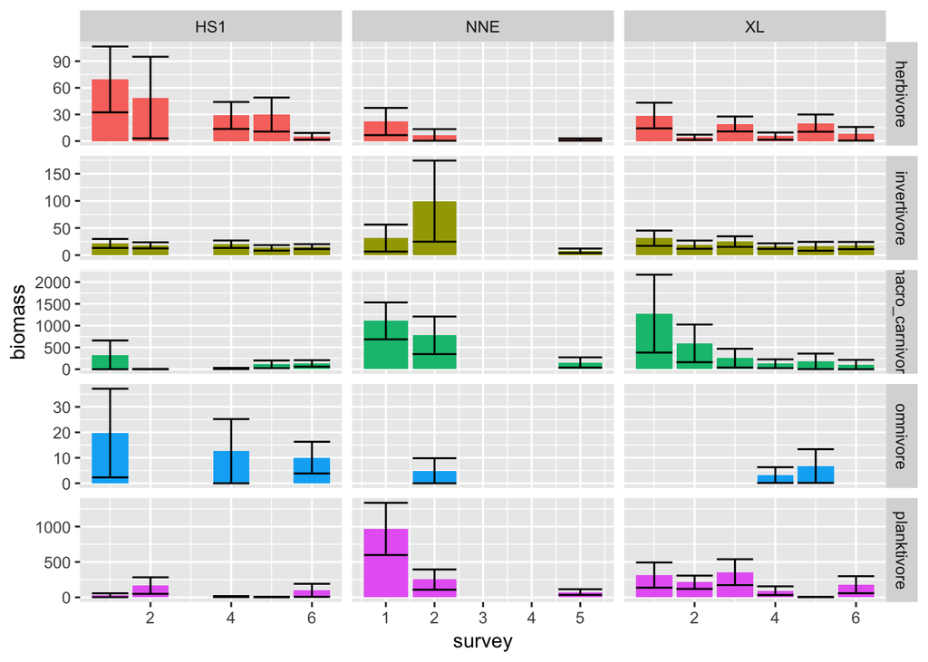

```r
ggplot(data = final_fish2, aes(x = survey, y=biomass, fill = trophic_guild)) + geom_bar(stat = "summary", fun.y = "mean") + facet_grid(trophic_guild~site, scales = "free") + theme(legend.position = "none") + stat_summary(geom = "errorbar", fun.data = mean_se)
```

```r
anova2 <- aov(sqrt(biomass) ~ site * trophic_guild, data = final_fish2)
summary.aov(anova2)
```

```
##                      Df Sum Sq Mean Sq F value   Pr(>F)
## site                  2   3896  1948.0   16.48 7.74e-08 ***
## trophic_guild         4   6202  1550.6   13.12 1.41e-10 ***
## site:trophic_guild    8   2799   349.9    2.96  0.00268 **
## Residuals          2613 308931   118.2
## ---
## Signif. codes:  0 '***' 0.001 '**' 0.01 '*' 0.05 '.' 0.1 ' ' 1
```

```r
TukeyHSD(anova2)
```

```
##   Tukey multiple comparisons of means
##     95% family-wise confidence level
##
## Fit: aov(formula = sqrt(biomass) ~ site * trophic_guild, data = final_fish2)
##
## $site
##              diff         lwr        upr     p adj
## NNE-HS1  3.339552  1.97523054  4.7038726 0.0000000
## XL-HS1   1.100689 -0.01231086  2.2136896 0.0533677
## XL-NNE  -2.238862 -3.59537824 -0.8823461 0.0003276
##
## $trophic_guild
##                                    diff        lwr        upr     p adj
## invertivore-herbivore       -0.04854607 -1.7476177  1.6505256 0.9999916
## macro_carnivore-herbivore    3.55453413  1.4913724  5.6176959 0.0000266
## omnivore-herbivore          -0.58791953 -3.6601546  2.4843156 0.9851204
## planktivore-herbivore        2.55511569  0.6421544  4.4680770 0.0025172
## macro_carnivore-invertivore  3.60308021  1.8859504  5.3202101 0.0000001
## omnivore-invertivore        -0.53937345 -3.3907813  2.3120344 0.9857537
## planktivore-invertivore      2.60366177  1.0702605  4.1370631 0.0000368
## omnivore-macro_carnivore    -4.14245366 -7.2247124 -1.0601949 0.0023112
## planktivore-macro_carnivore -0.99941844 -2.9284367  0.9295998 0.6184939
## planktivore-omnivore         3.14303522  0.1592284  6.1268421 0.0331284
##
## $`site:trophic_guild`
##                                                diff          lwr
## NNE:herbivore-HS1:herbivore             -0.82063589  -6.27964240
## XL:herbivore-HS1:herbivore              -0.33252869  -4.23181905
## HS1:invertivore-HS1:herbivore           -0.36339158  -3.51515046
## NNE:invertivore-HS1:herbivore            0.05256742  -3.84672294
## XL:invertivore-HS1:herbivore            -0.24669825  -3.40998097
## HS1:macro_carnivore-HS1:herbivore        0.84384278  -3.59569460
## NNE:macro_carnivore-HS1:herbivore        6.93218988   2.63706652
## XL:macro_carnivore-HS1:herbivore         3.60967617  -0.21966609
## HS1:omnivore-HS1:herbivore              -0.70193441  -6.16094092
## NNE:omnivore-HS1:herbivore              -1.16534112 -12.14815004
## XL:omnivore-HS1:herbivore               -1.28446755  -7.24073197
## HS1:planktivore-HS1:herbivore            0.03581461  -3.73125777
## NNE:planktivore-HS1:herbivore            5.50694508   1.60765472
## XL:planktivore-HS1:herbivore             3.11814277  -0.59311805
```

[output cut: 182 more lines]

```
## NNE:omnivore-HS1:omnivore               11.2084402 1.0000000
## XL:omnivore-HS1:omnivore                 6.5649842 1.0000000
## HS1:planktivore-HS1:omnivore             6.1967555 1.0000000
## NNE:planktivore-HS1:omnivore            11.7599499 0.0125719
## XL:planktivore-HS1:omnivore              9.2407206 0.5208140
## XL:omnivore-NNE:omnivore                11.7934024 1.0000000
## HS1:planktivore-NNE:omnivore            12.1839647 1.0000000
## NNE:planktivore-NNE:omnivore            17.7011448 0.7655388
## XL:planktivore-NNE:omnivore             15.2472749 0.9925377
## HS1:planktivore-XL:omnivore              7.2765466 0.9999884
## NNE:planktivore-XL:omnivore             12.8321673 0.0116903
## XL:planktivore-XL:omnivore              10.3237342 0.4233071
## NNE:planktivore-HS1:planktivore          9.3704208 0.0002005
## XL:planktivore-HS1:planktivore           6.7935890 0.2368930
## XL:planktivore-NNE:planktivore           1.4565960 0.7292470
```

# Reuslts

1. Significant differences in biomass of each trophic guild by site
2. Significantly more carnivores than invtertivores, omnivores and herbivores overall
3. Significanlty more planktivores than invertivores, omnivores and herbivores overall
4. No difference between biomass of carnivores and planktivores
5. NNE has significantly more planktivores and more carnivores than HS1
6. NNE has significatnly more carnivores and planktivores than herbivores and invertivores
7. XL has significantly more carnivores and planktivores than invertivores.

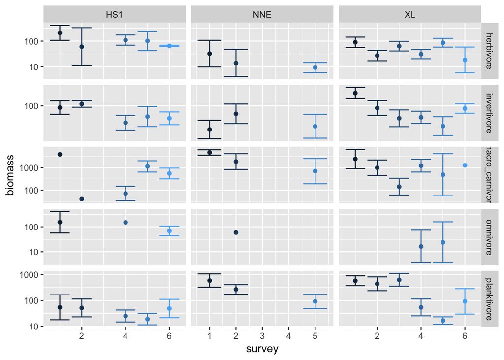

```r
ggplot(data = final_fish2, aes(x = survey, y=biomass, color = survey)) + geom_point(stat = "summary", fun.y = "mean") + facet_grid(trophic_guild~site, scales = "free") + theme(legend.position = "none") + stat_summary(geom = "errorbar", fun.data = mean_se) + scale_y_log10()
```

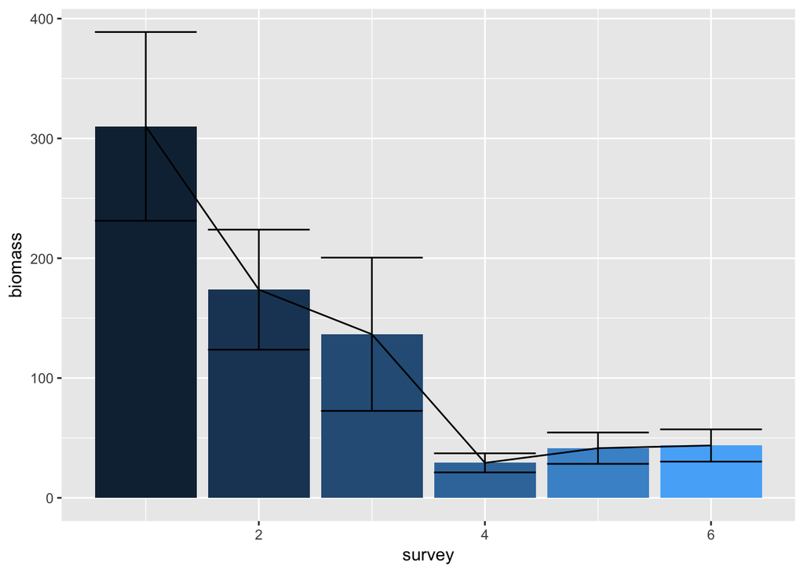

```r
ggplot(data = final_fish2, aes(x = survey, y=biomass, fill = survey)) + geom_bar(stat = "summary", fun.y = "mean") + stat_summary(geom = "errorbar", fun.data = mean_se) + geom_line(stat = "summary", fun.y = "mean") + theme(legend.position = "none")
```

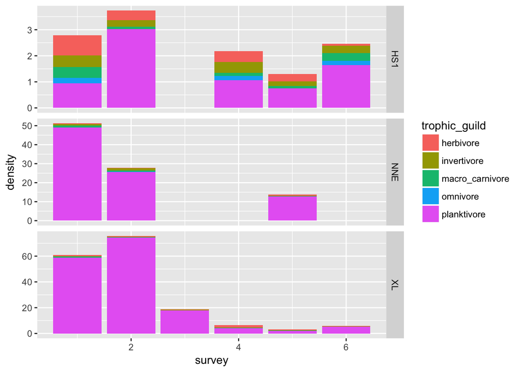

```r
ggplot(data = final_fish2, aes(x = survey, y=density, fill = trophic_guild)) + geom_bar(stat = "summary", fun.y = "mean") + facet_grid(site~., scales = "free")
```

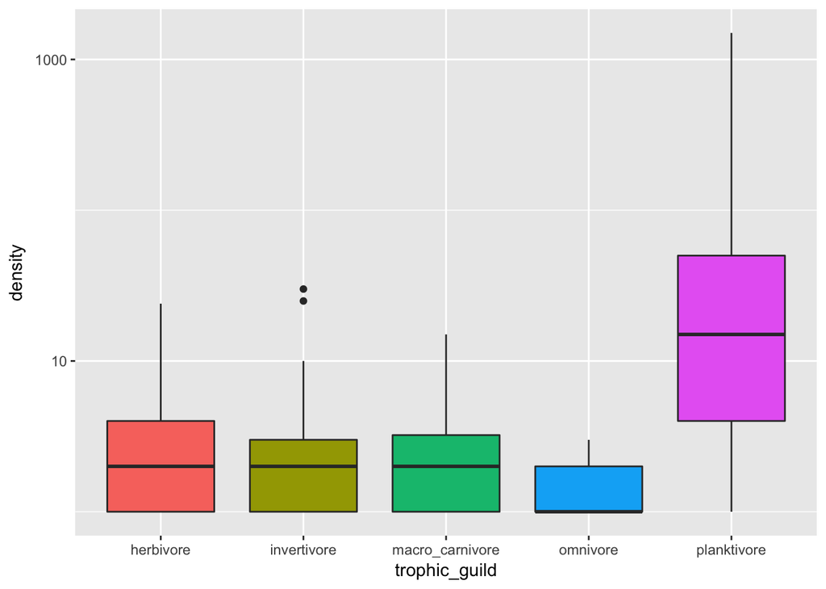

```r
ggplot(data = final_fish2, aes(x = trophic_guild, y = density, fill = trophic_guild)) + geom_boxplot() + theme(legend.position = "none") + scale_y_log10()
```

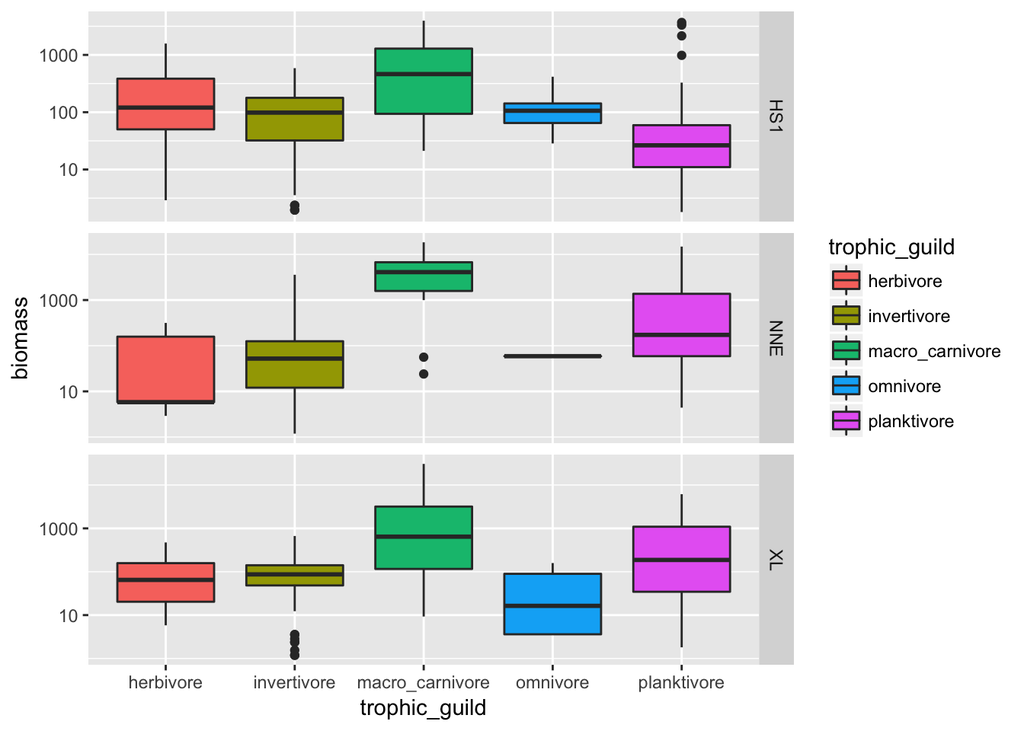

```r
ggplot(data = final_fish2, aes(x = trophic_guild, y = biomass, fill = trophic_guild)) + geom_boxplot() + scale_y_log10() + facet_grid(site~., scales = "free")
```

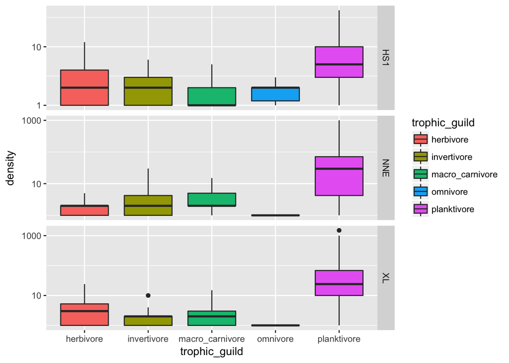

```r
ggplot(data = final_fish2, aes(x = trophic_guild, y = density, fill = trophic_guild)) + geom_boxplot() + scale_y_log10() + facet_grid(site~., scales = "free")
```

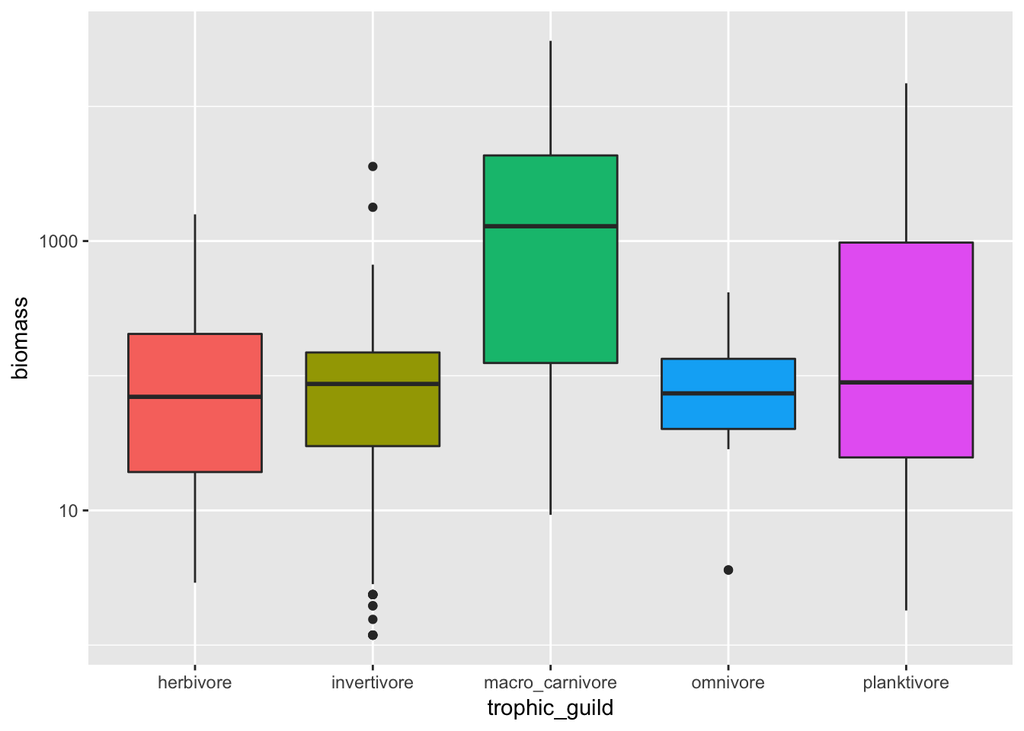

```r
ggplot(data = final_fish2, aes(x = trophic_guild, y = biomass, fill = trophic_guild)) + geom_boxplot() + theme(legend.position = "none") + scale_y_log10()
```

```r
anova4 <- aov(sqrt(density) ~ as.character(survey) * site/trophic_guild, data = final_fish2)
summary.aov(anova4)
```

```
##                                           Df Sum Sq Mean Sq F value
## as.character(survey)                       5    102   20.47   5.115
## site                                       2     79   39.59   9.892
## as.character(survey):site                  6     36    6.02   1.504
## as.character(survey):site:trophic_guild   48    921   19.19   4.793
## Residuals                               2566  10271    4.00
##                                           Pr(>F)
## as.character(survey)                    0.000113 ***
## site                                    5.26e-05 ***
## as.character(survey):site               0.172615
## as.character(survey):site:trophic_guild  < 2e-16 ***
## Residuals
## ---
## Signif. codes:  0 '***' 0.001 '**' 0.01 '*' 0.05 '.' 0.1 ' ' 1
```

```r
TukeyHSD(anova4)
```

```
##   Tukey multiple comparisons of means
##     95% family-wise confidence level
##
## Fit: aov(formula = sqrt(density) ~ as.character(survey) * site/trophic_guild, data = final_fish2)
##
## $`as.character(survey)`
##             diff        lwr          upr     p adj
## 2-1 -0.053075071 -0.4024592  0.296309039 0.9980710
## 3-1 -0.243702628 -0.6928845  0.205479276 0.6335157
## 4-1 -0.430720229 -0.7944514 -0.066989027 0.0096760
## 5-1 -0.436632516 -0.7860166 -0.087248406 0.0049938
## 6-1 -0.453619631 -0.8363623 -0.070876954 0.0095807
## 3-2 -0.190627557 -0.6443666  0.263111440 0.8379216
## 4-2 -0.377645158 -0.7469893 -0.008301034 0.0416487
## 5-2 -0.383557445 -0.7387812 -0.028333642 0.0255556
## 6-2 -0.400544560 -0.7886253 -0.012463833 0.0384489
## 4-3 -0.187017601 -0.6518942  0.277858950 0.8614451
## 5-3 -0.192929888 -0.6466689  0.260809108 0.8308728
## 6-3 -0.209917003 -0.6898147  0.269980670 0.8132773
## 5-4 -0.005912287 -0.3752564  0.363431836 1.0000000
## 6-4 -0.022899402 -0.4239453  0.378146457 0.9999842
## 6-5 -0.016987115 -0.4050678  0.371093612 0.9999958
##
## $site
##               diff         lwr        upr     p adj
## NNE-HS1  0.4178884  0.16684820 0.66892855 0.0002863
## XL-HS1   0.2618351  0.05703888 0.46663130 0.0077213
## XL-NNE  -0.1560533 -0.40565732 0.09355075 0.3074810
##
## $`as.character(survey):site`
##                    diff         lwr         upr     p adj
## 2:HS1-1:HS1  0.04628561 -0.68165461  0.77422582 1.0000000
## 3:HS1-1:HS1          NA          NA          NA        NA
## 4:HS1-1:HS1 -0.00106738 -0.66643973  0.66430497 1.0000000
## 5:HS1-1:HS1 -0.07993008 -0.78247785  0.62261770 1.0000000
## 6:HS1-1:HS1 -0.01871733 -0.69208666  0.65465201 1.0000000
## 1:NNE-1:HS1  0.81552580  0.11297803  1.51807358 0.0065838
## 2:NNE-1:HS1  0.57268332 -0.12986446  1.27523109 0.2842334
## 3:NNE-1:HS1          NA          NA          NA        NA
## 4:NNE-1:HS1          NA          NA          NA        NA
```

[output cut: 8143 more lines]

```
## 2:XL:planktivore-1:XL:planktivore            2.115903278 1.0000000
## 3:XL:planktivore-1:XL:planktivore            0.872665300 0.9988640
## 4:XL:planktivore-1:XL:planktivore           -0.055947345 0.0317139
## 5:XL:planktivore-1:XL:planktivore           -0.400252083 0.0011859
## 6:XL:planktivore-1:XL:planktivore            0.290580046 0.2866462
## 3:XL:planktivore-2:XL:planktivore            0.767003714 0.9887687
## 4:XL:planktivore-2:XL:planktivore           -0.161608931 0.0125816
## 5:XL:planktivore-2:XL:planktivore           -0.505913669 0.0003744
## 6:XL:planktivore-2:XL:planktivore            0.184918460 0.1640522
## 4:XL:planktivore-3:XL:planktivore            1.081629047 0.9999993
## 5:XL:planktivore-3:XL:planktivore            0.737324309 0.9812007
## 6:XL:planktivore-3:XL:planktivore            1.428156438 1.0000000
## 5:XL:planktivore-4:XL:planktivore            1.665936954 1.0000000
## 6:XL:planktivore-4:XL:planktivore            2.356769083 1.0000000
## 6:XL:planktivore-5:XL:planktivore            2.701073821 1.0000000
```

## Results anova 4

1. Significant differences by site and by survey but not by the interaction, i.e. all sites follow the same trend.
2. Density is significantly higher at NNE and XL than HS1.
3. Density is significantly higher at the first and second time points compared to surveys 4, 5, and 6

*Need to confirm data meets assumptions after transformation*

```r
anova5 <- aov(sqrt(density) ~ trophic_guild, data = final_fish2)
summary.aov(anova5)
```

```
##                 Df Sum Sq Mean Sq F value Pr(>F)
## trophic_guild    4    587  146.72   35.56 <2e-16 ***
## Residuals     2623  10823    4.13
## ---
## Signif. codes:  0 '***' 0.001 '**' 0.01 '*' 0.05 '.' 0.1 ' ' 1
```

```r
TukeyHSD(anova5)
```

```
##   Tukey multiple comparisons of means
##     95% family-wise confidence level
##
## Fit: aov(formula = sqrt(density) ~ trophic_guild, data = final_fish2)
##
## $trophic_guild
##                                    diff        lwr       upr     p adj
## invertivore-herbivore       -0.02512448 -0.3425364 0.2922875 0.9995165
## macro_carnivore-herbivore   -0.04898919 -0.4344186 0.3364402 0.9968936
## omnivore-herbivore          -0.14394958 -0.7178889 0.4299898 0.9598354
## planktivore-herbivore        1.11733560  0.7599659 1.4747053 0.0000000
## macro_carnivore-invertivore -0.02386471 -0.3446502 0.2969208 0.9996218
## omnivore-invertivore        -0.11882510 -0.6515106 0.4138604 0.9737287
## planktivore-invertivore      1.14246007  0.8559978 1.4289223 0.0000000
## omnivore-macro_carnivore    -0.09496039 -0.6707723 0.4808515 0.9915242
## planktivore-macro_carnivore  1.16632478  0.8059554 1.5266942 0.0000000
## planktivore-omnivore         1.26128518  0.7038655 1.8187048 0.0000000
```

```r
anova6 <- aov(sqrt(biomass) ~ trophic_guild, data = final_fish2)
summary.aov(anova6)
```

```
##                 Df Sum Sq Mean Sq F value   Pr(>F)
## trophic_guild    4   7989  1997.3   16.69 1.61e-13 ***
## Residuals     2623 313839   119.6
## ---
## Signif. codes:  0 '***' 0.001 '**' 0.01 '*' 0.05 '.' 0.1 ' ' 1
```

```r
TukeyHSD(anova6)
```

```
##   Tukey multiple comparisons of means
##     95% family-wise confidence level
##
## Fit: aov(formula = sqrt(biomass) ~ trophic_guild, data = final_fish2)
##
## $trophic_guild
##                                     diff        lwr        upr     p adj
## invertivore-herbivore       -0.001593012 -1.7108376  1.7076516 1.0000000
## macro_carnivore-herbivore    4.104998890  2.0294843  6.1805135 0.0000007
## omnivore-herbivore          -0.731043165 -3.8216728  2.3595865 0.9674742
## planktivore-herbivore        3.030642875  1.1062280  4.9550577 0.0001729
## macro_carnivore-invertivore  4.106591901  2.3791810  5.8340028 0.0000000
## omnivore-invertivore        -0.729450153 -3.5979304  2.1390301 0.9578042
## planktivore-invertivore      3.032235887  1.4896536  4.5748182 0.0000009
## omnivore-macro_carnivore    -4.836042054 -7.9367553 -1.7353288 0.0002076
## planktivore-macro_carnivore -1.074356015 -3.0149239  0.8662119 0.5552021
## planktivore-omnivore         3.761686040  0.7600141  6.7633580 0.0057179
```

# Results Anova 5 and 6

1. Higher density of planktivores than any other trophic group. No difference among others
2. Higher biomass of carnivores and planktivores than all other groups. No difference between planktivores and carnivores.